# Lab-05 Replication

## Introduction

This file contains the replication code for Lab-05, which focuses on understanding the distribution of random variables and normality testing in `R`.

## Dependencies

This lab requires the `testDriveR` package for data and the `moments` and `nortest` packages for normality testing:

```r
library(testDriveR)
library(moments)
library(nortest)
```

## Part 1 - Binomial Distribution

### Question 1

The following function finds the probability under the binomial distribution for more than *k* outcomes:

```r
pbinom(24, size = 250, prob = .4, lower.tail = FALSE)
```

```
[1] 1
```

The probability of more than 24 successes in a series of 250 trials where the probability of success is $p=0.4$ is nearly 1. `R` rounds the reported probability in this case.

### Question 2

The following function finds the probability under the binomial distribution for *k* or fewer outcomes:

```r
pbinom(25, size = 250, prob = .4, lower.tail = TRUE)
```

```
[1] 2.706299e-26
```

The scientific notation reported here means that the probability of 25 or fewer successes in a series of 250 trials where the probability of success is $p=0.4$ is nearly 0.

### Question 3

The following function finds the probability under the binomial distribution for exactly *k* outcomes:

```r
dbinom(25, size = 250, prob = .4)
```

```
[1] 2.26111e-26
```

The scientific notation reported here means that the probability of exactly 25 successes in a series of 250 trials where the probability of success is $p=0.4$ is nearly 0.

## Part 2 - Poisson Distribution

### Question 4

The following function finds the probability under the poisson distribution for more than *k* outcomes. Note that lambda ($\lambda$) is the product of $n*p$:

```r
lambda = 1000 * .025
ppois(4, lambda = lambda, lower.tail = FALSE)
```

```
[1] 0.9999997
```

The probability of observing more than 4 failures is $p=0.999$, or nearly 1. This means that we are almost certain to see more than 4 rockets fail.

### Question 5

```r
dpois(18, lambda = lambda)
```

```
[1] 0.03156582
```

The probability of observing exactly 18 failures is $p=0.032$. In other words, it is highly unlikely that we would see exactly 18 failures.

### Question 6

The following function finds the probability under the poisson distribution for *k* or fewer outcomes. This question relies on the $\lambda$ calculation from the previous question.

```r
ppois(15, lambda = lambda, lower.tail = TRUE)
```

```
[1] 0.02229302
```

The probability of observing 15 or fewer failures is $p=0.022$. Like the previous probabiliy, it is highly unlikely that we would see this outcome.

## Part 3 - Normal Distribution

### Question 7

This question has two pieces that need to be addressed. The code below calculates the z-score and then looks up the cumulative probability of that z-score under the standard normal distribution. We use the formula $z = \frac{x-\bar{x}}{s}$ to calculate the z-score.

```r
zScore <- (25-21)/3
pnorm(zScore, mean = 0, sd = 1, lower.tail = TRUE)
```

```
[1] 0.9087888
```

## Part 4 - Skew and Kurtosis by Hand

See the `pdf` in the `Week-05/Lab/` repo for the replication by hand.

We can check our results using the following code. First, we need to read the vector of values from the assignment sheet into `R`:

```r
q8 <- c(1,4,3,2,4,2,1,4,3,3)
```

The skewness of `q8` is:

```r
skewness(q8)
```

```
[1] -0.2885049
```

Given that the skew value is $sk=-0.289$. This indicates some minor negative skew. In other words, it is a distribution with a long left tail. Since it is within the -2 to 2 range, we have a distribution that does not appear to depart significantly from the standard normal.

The kurtosis of `q8` is:

```r
kurtosis(q8)
```

```
[1] 1.760604
```

Given the kurtosis value of $k=1.761$, we have an indication of a platykurtic distribution since it is less than 3. This does not give us any concerns about the distribution since it is less than 5.

## Part 5 - Normality Testing in `R`

### Question 9

The following code loads the needed data from `testDriveR` into a data frame:

```r
autoData <- auto17
```

#### Question 9a - Skew

The following function will report the skew of `fuelCost`:

```r
skewness(autoData$fuelCost)
```

```
[1] 0.7116702
```

Given that the skew value is $sk=0.712$. This indicates some minor positive skew. In other words, it is a distribution with a long right tail. Since it is within the -2 to 2 range, we have a distribution that does not appear to depart significantly from the standard normal.

#### Question 9b - Kurtosis

The following function will report the kurtosis of `fuelCost`:

```r
kurtosis(autoData$fuelCost)
```

```
[1] 4.047727
```

Given the kurtosis value of $k=4.048$, we have an indication of a slightly leptokurtic distribution since it is greater than 3. This does not give us any concerns about the distribution since it is less than 5.

#### Question 9c - Q-Q Plot

The following pair of functions creates a plot with both the q-q distribution and the q-q line:

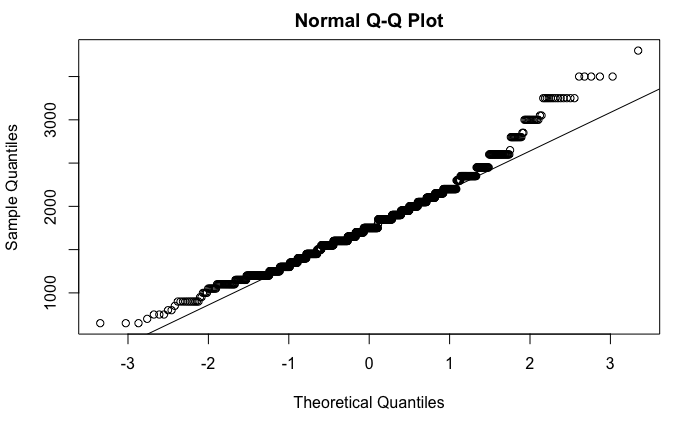

```r
qqnorm(autoData$fuelCost); qqline(autoData$fuelCost)
```

The plot shows so deviations from normal in both tails. You can see the right skew by looking at the values on the right side of the distribution, which appear to have a greater departure from normal than those on other areas of the distribution.

#### Question 9d - Shapiro-Francia Test

The following function produces the hypothesis tests results for the Shapiro-Francia test:

```r
sf.test(autoData$fuelCost)
```

```
    Shapiro-Francia normality test

data:  autoData$fuelCost
W = 0.96974, p-value = 7.183e-14
```

The results of the Shapiro-Francia test (W’ = 0.970, p < 0.001) suggest that the distribution does have some departures from normal. These results confict with the findings of the q-q plot, the skew, and kurtosis, which all point to a slightly non-normal distribution that does not depart so far from normal as to be problematic. This is an example of the competing information that I discussed in class. In this case, I would lean away from the results of the Shapiro-Francia test and towards the other three sources of information since they all point in the “same direction” towards an only slightly abnormal distribution.